# Notebook

```python
pylab inline
```

```python
%load_ext autoreload
```

### Setup

```python
import pandas as pd
import numpy as np
np.random.RandomState(100)
from sqlalchemy import create_engine
import os
import sys
import scipy.stats

from joblib import Parallel, delayed
import multiprocessing
num_cores = multiprocessing.cpu_count()
print "%s cores available for parallel processing" % num_cores

sys.path.append('mpscraper')
from mpscraper.cfgdb import cfg
sys.path.append('antools')
import antools.randomstuff as rd
import antools.reduction as red
import antools.utilities as uf
import antools.visualization as viz
import antools.modeling as mo

import pandas as pd
import numpy as np
import seaborn as sns
sns.set_style('white')
import matplotlib.pyplot as plt
import scipy.stats

from sklearn.metrics.pairwise import pairwise_distances
import sklearn.cross_validation
from sklearn.ensemble import RandomForestRegressor
from sklearn.ensemble import RandomForestClassifier
from sklearn.linear_model import LinearRegression
from sklearn.svm import SVC
from sklearn.linear_model import Ridge
from sklearn.metrics import f1_score
```

```
4 cores available for parallel processing
```

```python
import sys, os
rootdir=os.getcwd()
while 'Projects' in rootdir:
    rootdir=os.path.dirname(rootdir)
projdir=os.path.join(rootdir, 'Projects','cragcrunch','data')
```

### Load in preprocessed data

```python
engine = create_engine('mysql://%s@%s/%s?charset=%s&use_unicode=%s&passwd=%s' %(cfg.user, cfg.host, cfg.dbname, cfg.charset, cfg.use_unicode, cfg.passwd), pool_recycle=3600)
cdf = pd.read_sql("SELECT * from climb_prepped where region = 'New Hampshire'", engine, index_col='index')
adf = pd.read_sql("SELECT * from area_prepped where region = 'New Hampshire'", engine, index_col='index')
climbs=list(cdf.climbid.unique())
print "loading %s climbs" %(len(climbs))
cldf = pd.read_sql("SELECT * from climber_prepped", engine, index_col='index')
hdf= pd.read_sql("SELECT * from hits_prepped", engine, index_col='index')
sdf= pd.read_sql("SELECT * from stars_prepped", engine, index_col='index')
gdf= pd.read_sql("SELECT * from grades_prepped", engine, index_col='index')
codf= pd.read_sql("SELECT * from comments_prepped", engine, index_col='index')
tdf= pd.read_sql("SELECT * from ticks_prepped", engine, index_col='index')
```

```
loading 1303 climbs
```

```python
like_mat= pd.read_sql("SELECT * from like_matrix", engine, index_col='index')
star_mat= pd.read_sql("SELECT * from star_matrix", engine, index_col='index')
```

```python
minratings=5
users=sdf[sdf['climb'].isin(climbs)]['climber'].unique().astype(int)
users=[u for u in users if u in cldf.climberid.values]
print "starting with %s users" %len(users)
users=[u for u in users if len(sdf[sdf['climber']==u]['climb'].values)>=minratings]
usesdf=sdf[sdf['climber'].isin(users)]
usesdf['other_rounded']=[np.round(val) for val in usesdf['other_avg']]
usesdf=usesdf[(usesdf['starsscore']>0) & (usesdf['other_rounded']>0)]
usesdf['climbid']=usesdf['climb']
cdf=cdf[cdf['climbid'].isin(usesdf['climb'].unique())]
print "reducing to %s users who have greater than or equal to %s ratings provided" %(len(users), minratings)
```

[output not shown]

### Prep text features

```python
allterms=uf.loadpickledobjects(os.path.join(projdir, 'climbingterms.pkl'))[0]
descripfeats, ndf=uf.gettextfeats(cdf, allterms)
```

### Quick visualization of the data

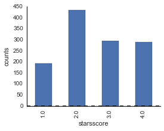

```python
#how are stars dstributed()
f,ax=plt.subplots(figsize=[4,3])
usesdf.groupby('starsscore').count().climb.plot(kind='bar', grid=False,ax=ax)
ax.set_ylabel('counts')
sns.despine()
```

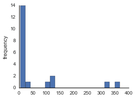

```python
#how many climbs per climber?
f,ax=plt.subplots(figsize=[4,3])
usesdf.groupby('climber').count().climb.hist(bins=20, grid=False,ax=ax)
ax.set_ylabel('frequency')
sns.despine()
```

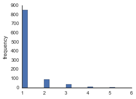

```python
#how many climbers per climb?
f,ax=plt.subplots(figsize=[4,3])
usesdf.groupby('climb').count().climber.hist(bins=20, grid=False,ax=ax)
ax.set_ylabel('frequency')
sns.despine()
```

### Model Comparison

I'll start with some really naive models that can serve as baselines I want to beat

```python
compare={'name':[],'acc':[],'recall':[],'precision':[],'f1':[]}
resultsdict={}
```

### Absolute dumbest model guesses randomly

```
4 way accuracy 0.238
4 way f1 0.246
4 way precision 0.236
4 way recall 0.257
```

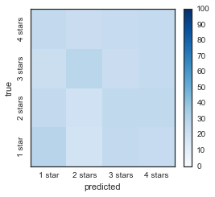

```python
name='random'
dumbdf=pd.DataFrame(data={'starsscore':usesdf['starsscore'].values,'random':[np.random.choice(usesdf.starsscore.values) for x in range(len(usesdf))],'user':usesdf['climber'].values,'climbid':usesdf['climb'].values})
acc, precision, recall, f1=mo.round2score(dumbdf, 'starsscore', 'random', compare)
compare['name'].append(name)
propdf=viz.plotresults(dumbdf, 'starsscore', 'random')
dumbdf['score']=(dumbdf['starsscore'].values==dumbdf['random'].values).astype(float)
resultsdict[name]=[dumbdf,[]]
```

### Another really dumb model guesses most frequent rating label

```
4 way accuracy 0.360
4 way f1 nan
4 way precision nan
4 way recall 0.000
```

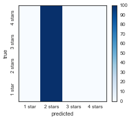

```python
name='mostfrequent'
mode=scipy.stats.mode(usesdf['starsscore'].values)[0][0]
modedf=pd.DataFrame(data={'starsscore':usesdf['starsscore'].values, 'mostfrequent':[mode for x in range(len(usesdf))],'user':usesdf['climber'].values,'climbid':usesdf['climb'].values})
acc, precision, recall, f1=mo.round2score(modedf, 'starsscore', 'mostfrequent', compare)
compare['name'].append(name)
propdf=viz.plotresults(modedf, 'starsscore', 'mostfrequent')
modedf['score']=(modedf['starsscore'].values==modedf['mostfrequent'].values).astype(float)
resultsdict[name]=[modedf,[]]
```

```python
def getavg(starid, climber, sdf=None):
    udf=sdf[(sdf['climber']==climber) & (sdf['starid']!=starid)]
    return udf['starsscore'].mean()
usesdf['user_avg']=usesdf.apply(lambda x:getavg(x['starid'], x['climber'], sdf=usesdf), axis=1)
usesdf['rounded_user_avg']=[np.round(x) for x in usesdf.user_avg.values]
```

```python
savedf=pd.DataFrame(data={'climbid':usesdf['climb'].values, 'user':usesdf['climber'].values})
savedf['score']=(usesdf['user_avg'].values==usesdf['starsscore'].values).astype(float)
```

```
4 way accuracy 0.385
4 way f1 0.320
4 way precision 0.982
4 way recall 0.191
```

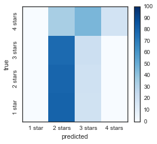

```python
%autoreload
savedf=pd.DataFrame(data={'climbid':usesdf['climb'].values, 'user':usesdf['climber'].values})
savedf['score']=(usesdf['user_avg'].values==usesdf['starsscore'].values).astype(float)
name='targetmode'
acc, precision, recall, f1=mo.round2score(usesdf, 'starsscore', 'rounded_user_avg', compare)
compare['name'].append(name)
propdf=viz.plotresults(usesdf, 'starsscore', 'rounded_user_avg')
resultsdict[name]=[savedf,[]]
```

### A really simple model makes recommendations based on the ratings of the full remaining group

```python
savedf=pd.DataFrame(data={'climbid':usesdf['climb'].values, 'user':usesdf['climber'].values})
savedf['score']=(usesdf['other_rounded'].values==usesdf['starsscore'].values).astype(float)
```

```
4 way accuracy 0.559
4 way f1 0.722
4 way precision 0.757
4 way recall 0.691
```

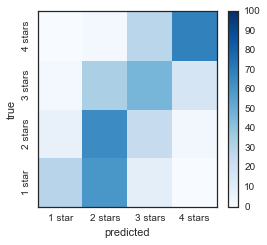

```python
%autoreload
name='other_avg'
acc, precision, recall, f1=mo.round2score(usesdf, 'starsscore', 'other_rounded', compare)
compare['name'].append(name)
propdf=viz.plotresults(usesdf, 'starsscore', 'other_rounded')
resultsdict[name]=[savedf,[]]
```

### Potential features

1. climber x climb preference matrix
2. unstructured text and other attributes (length, elevation) associated with each climb
3. overall popularity

--> can I use this information to build a model that predicts the rating that an individual user gives to a specific climb?

### Validation approach

I will use a variety of algorithms and feature sets to predict individual user ratings. To validate the model, I use leave-one-out cross validation. Can I predict the rating that an individual climber gives a climb based on their ratings of other climbs? Leave-on-out cross-validation has known [limitations](http://www.russpoldrack.org/2012/12/the-perils-of-leave-one-out.html) but is useful in the present context where there can be a very small number of exemplars for each individual climber. On each iteration, I train on all climbs but one, and predict the user's remaining climb.

read this: http://www.russpoldrack.org/2012/12/the-perils-of-leave-one-out.html

```python
#set general model params
clf=mo.classifier('rfc') #for not using random forest, will explore other options below
```

### A smart model might use attributes of other climbs the user likes

```python
#features = all text and non text attributes from climb pages (using features selected in preprocessing steps)
%autoreload
numericfeats=['pitch','pageviews','numerizedgrade']
name='allterms'
cfeatures=['%s_description' %term for term in allterms]
sfeatures=[]
print "classifying using %s features (%s)" %(len(cfeatures)+len(sfeatures), name)
this_ndf=ndf[['climbid']+cfeatures].dropna()
print this_ndf.shape
summarydf, resultsdf, emptyfeats=mo.classify(clf,users, sfeatures, cfeatures, this_ndf, usesdf, minratings=minratings)
resultsdict[name]=[summarydf, resultsdf]
```

```
classifying using 204 features (allterms)
(521, 205)
```

```
classifying with allterms
```

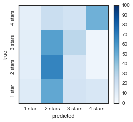

```
4 way accuracy 0.450
4 way f1 0.535
4 way precision 0.587
4 way recall 0.491
```

```python
%autoreload
name='allterms'
print "classifying with %s" %name
summarydf, resultsdf=resultsdict[name]
viz.plotresults(resultsdf, 'true_rating', 'feat_pred')
acc, precision, recall, f1=mo.round2score(resultsdf, 'true_rating', 'feat_pred', compare)
compare['name'].append(name)
```

### A smart model might also use the ratings of climbers

Specifically, we can include as features the ratings of each climb by each other user (here using a binarized "like" matrix). In contrast to using the group average, training on each individual climber's ratings allows the model to learn which other climber's ratings are most predictive of the target's.

```python
clf=mo.classifier('rfc')
```

```python
#features=vector of "likes"/"not-likes" by other climbers
%autoreload
name='user_sim'
cfeatures=list(like_mat.columns.values)
cfeatures.remove('climbid')
sfeatures=[]
print "classifying using %s features" %(len(cfeatures)+len(sfeatures))
summarydf, resultsdf, emptyfeats=mo.classify(clf,users, sfeatures, cfeatures, like_mat, usesdf, minratings=minratings, dropself=True)
resultsdict[name]=[summarydf, resultsdf]
```

```
classifying using 105 features
```

```
classifying with user_sim
```

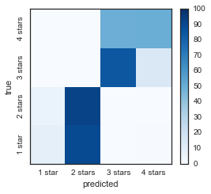

```
4 way accuracy 0.693
4 way f1 0.589
4 way precision 0.710
4 way recall 0.503
```

```python
%autoreload
name ='user_sim'
print "classifying with %s" %name
summarydf, resultsdf=resultsdict[name]
viz.plotresults(resultsdf, 'true_rating', 'feat_pred')
acc, precision, recall, f1=mo.round2score(resultsdf, 'true_rating', 'feat_pred', compare)
compare['name'].append(name)
```

### Combining all features

```python
clf=mo.classifier('rfc')
```

```python
#features=climb page attributes, text features, and like info
%autoreload
name='combined'
cfeatures=list(like_mat.columns)+descripfeats+numericfeats
cfeatures.remove('climbid')
sfeatures=['other_avg']
print "classifying using %s features" %(len(cfeatures)+len(sfeatures))
full_ndf=ndf[['climbid']+descripfeats+numericfeats]
full_ndf=pd.merge(full_ndf, like_mat, on='climbid', how='inner')
full_ndf.index=full_ndf['climbid'].values
full_ndf=full_ndf[full_ndf['climbid'].isin(sdf.climb.unique())]
full_ndf=full_ndf.dropna()
summarydf, resultsdf, emptyfeats=mo.classify(clf,users, sfeatures, cfeatures, full_ndf, usesdf, minratings=minratings, dropself=True, datadir=projdir)
resultsdict[name]=[summarydf, resultsdf]
```

```
classifying using 313 features
```

```
classifying with combined
```

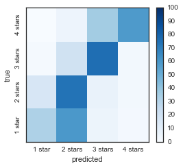

```
4 way accuracy 0.659
4 way f1 0.672
4 way precision 0.786
4 way recall 0.587
```

```python
%autoreload
name='combined'
print "classifying with %s" %name
summarydf, resultsdf=resultsdict[name]
viz.plotresults(resultsdf, 'true_rating', 'feat_pred')
acc, precision, recall, f1=mo.round2score(resultsdf, 'true_rating', 'feat_pred', compare)
compare['name'].append(name)
```

### Model optimization

The analyses above suggest that we want to build a model that incorporates three kinds of information: - climb attributes - overall climb popularity - ratings of individual users (e.g. preferences of similar climbers)

A model that naively combines these features does reasonably well, but I can try to improve performance by toggling the following: - algorithm (RFC vs. SVM vs. Logistic Regression) - features (try dimensionality reduction/feature selection methods) - model parameters (e.g. C param if using SVM)

### Which algorithm? (empirical)

```python
#svm
clf=mo.classifier('svm')
name='combined_svm'
print "classifying using %s features" %(len(cfeatures)+len(sfeatures))
summarydf, resultsdf, emptyfeats=mo.classify(clf,users, sfeatures, cfeatures, full_ndf, usesdf, minratings=minratings, dropself=True)
resultsdict[name]=[summarydf, resultsdf]
```

```
classifying using 313 features
```

```python
#multinomial logistic
clf=mo.classifier('logistic')
name='combined_logistic'
print "classifying using %s features" %(len(cfeatures)+len(sfeatures))
summarydf, resultsdf, emptyfeats=mo.classify(clf,users, sfeatures, cfeatures, full_ndf, usesdf, minratings=minratings, dropself=True)
resultsdict[name]=[summarydf, resultsdf]
```

```
classifying using 313 features
```

```
classifying with combined
```

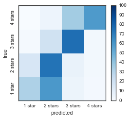

```
4 way accuracy 0.659
4 way f1 0.672
4 way precision 0.786
4 way recall 0.587

classifying with combined_svm
```

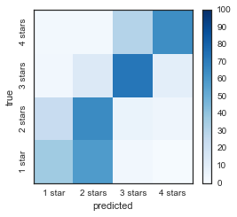

```
4 way accuracy 0.627
4 way f1 0.636
4 way precision 0.632
4 way recall 0.640

classifying with combined_logistic
```

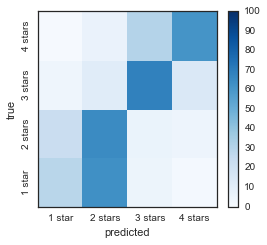

```
4 way accuracy 0.600
4 way f1 0.582
4 way precision 0.554
4 way recall 0.613
```

```python
for name in ['combined','combined_svm','combined_logistic']:
    print ""
    print "classifying with %s" %name
    summarydf, resultsdf=resultsdict[name]
    viz.plotresults(resultsdf, 'true_rating', 'feat_pred')
    acc, precision, recall, f1=mo.round2score(resultsdf, 'true_rating', 'feat_pred', compare)
    compare['name'].append(name)
```

Random Forests outperforms SVM and logisic (on these data and with these fairly arbitrary parameters). Combining the advantages of RFC describe above, and it's apparently strong performance here, I'll focus subsequent analyses on random forests

### Optimize parameters of chosen model

```python
poss_n=range(1,150,10)
results=[]
for n in poss_n:
    clf=mo.classifier('rfc')
    clf.n_estimators=n
    name='combined_rfc_n_est_%s' %(n)
    summarydf, resultsdf, emptyfeats=mo.classify(clf,users, sfeatures, cfeatures, full_ndf, usesdf, minratings=minratings, dropself=True)
    resultsdict[name]=[summarydf, resultsdf]
    results.append(summarydf['score'].mean())
```

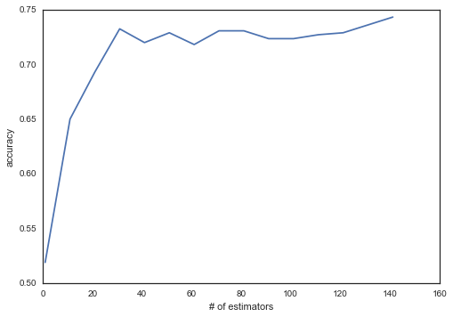

```python
f,ax=plt.subplots()
ax.plot(range(1,150,10),results)
ax.set_xlabel('# of estimators')
ax.set_ylabel('accuracy')
```

Plotting accuracy as a function of the # of estimators, we see that the accuracy increases dramatically until about 20-30 trees and then levels off. there is a very mild increase in accuracy with increasing k, but computation time scales with k, so we want the minumum K that gives us the desired accuracy. I'll go with k=80.

```python
nestimators=80
```

### Feature selection

To be able to quickly incorporate new users who don't have a full climbing history, I want to identify a relatively simple, intuitive feature vector that can be used to provide predictions for a new user based on a few indicated preferences. So, I want to reduce this space of features. Many approaches to dimensionality reduction (i.e. PCA) reduce features into components that are linear combinations of the initial input space. However, the most intuitive inputs for the user are simple words like those contained in initial set of algorithmically selected features.

### Forward stepwise iterative regression

Before diving into identifying dimensions, I want to explore the space of features a bit more and get a sense of which features explain the most unique variance across climbs. to do this, I do an iterative regression analysis (take individual feature with highest R2 and then iterate with the residuals) on the climb x feature matrix

```
right_description, arete_description, crack_description, start_description, route_description, feet_description, climb_description, boulder_description, face_description, good_description, moves_description, just_description, hand_description, slab_description, fun_description, crux_description, bol…
```

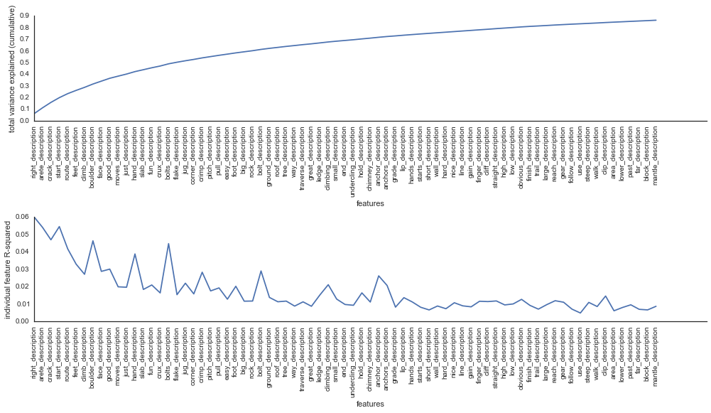

```python
%autoreload
avgs=ndf[descripfeats]
rx=mo.iterativeregression(avgs, plotit=True, limit=75)
```

```python
#saving feature importances
%autoreload
clf=mo.classifier('rfc')
clf.n_estimators=nestimators
results=[]
resutlsdict={}
name='combined_feature_selection'
print "classifying using %s features" %(len(cfeatures)+len(sfeatures))
summarydf, resultsdf, informativefeats=mo.classify(clf,users, sfeatures, cfeatures, full_ndf, usesdf, minratings=minratings, dropself=True, getfeats=True)
resultsdict[name]=[summarydf, resultsdf]
results.append(summarydf['score'].mean())
```

```
classifying using 313 features
```

```
classifying with combined_feature_selection
```

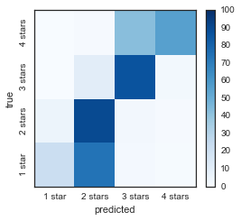

```
4 way accuracy 0.738
4 way f1 0.672
4 way precision 0.840
4 way recall 0.560
```

```python
name='combined_feature_selection'
print "classifying with %s" %name
summarydf, resultsdf=resultsdict[name]
viz.plotresults(resultsdf, 'true_rating', 'feat_pred')
acc, precision, recall, f1=mo.round2score(resultsdf, 'true_rating', 'feat_pred', compare)
compare['name'].append(name)
```

#### Feature selection approach:

[output not shown]

```python
featdf=informativefeats[[col for col in informativefeats.columns if col != 'climber']].T
featdf['T_value']=featdf.apply(lambda x:scipy.stats.ttest_1samp(x.values, 0)[0], axis=1)
featdf['P_value']=featdf.apply(lambda x:scipy.stats.ttest_1samp(x.values, 0)[1], axis=1)
sorteddf=featdf.sort(columns='T_value', ascending=False).iloc[:100,:]
```

```python
f,ax = plt.subplots(figsize=[16,2])
featdf.sort(columns='T_value', ascending=False).T_value.plot(kind="bar", ax=ax, grid=False)
```

[output not shown]

```python
finafeats=uf.makecols(sorteddf)
```

### Assess predictive power of combined with reduced text space

```python
%autoreload
name='combined_reduced'
clf=mo.classifier('rfc')
clf.n_estimators=nestimators
cfeatures=list(like_mat.columns)+finalfeats
cfeatures.remove('climbid')
sfeatures=['other_avg']
print "classifying using %s features" %(len(cfeatures)+len(sfeatures))
full_ndf=ndf[['climbid']+finalfeats]
full_ndf=pd.merge(full_ndf, like_mat, on='climbid', how='inner')
full_ndf.index=full_ndf['climbid'].values
full_ndf=full_ndf[full_ndf['climbid'].isin(sdf.climb.unique())]
full_ndf=full_ndf.dropna()
summarydf, resultsdf, informativefeats=mo.classify(clf,users, sfeatures, cfeatures, full_ndf, usesdf, minratings=minratings, dropself=True, datadir=projdir)
resultsdict[name]=[summarydf, resultsdf]
```

```
classifying using 206 features
```

```
classifying with combined_reduced
```

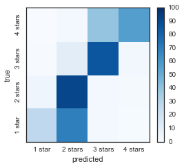

```
4 way accuracy 0.749
4 way f1 0.672
4 way precision 0.811
4 way recall 0.573
```

```python
name='combined_reduced'
print "classifying with %s" %name
summarydf, resultsdf=resultsdict[name]
viz.plotresults(resultsdf, 'true_rating', 'feat_pred')
acc, precision, recall, f1=mo.round2score(resultsdf, 'true_rating', 'feat_pred', compare)
compare['name'].append(name)
```

```python
', '.join(finalfeats)
```

```
'moves_description, pitches_description, flakes_description, anchors_description, pitch, bolts_description, gully_description, climb_description, base_description, great_description, trad_description, grade_description, rock_description, follow_description, clipping_description, cliff_description, p…
```

### Feature pruning

```python
askterms=['flakes', 'hand','tricky','undercling','slab','clipping','technical','boulder','bulge','bolted','steep', 'jug','chimney', 'crack','crux','roof','flake','cracks','traverse','pitch','crimp']
askfeats=[a+'_description' for a in askterms]
print askterms
```

```
['flakes', 'hand', 'tricky', 'undercling', 'slab', 'clipping', 'technical', 'boulder', 'bulge', 'bolted', 'steep', 'jug', 'chimney', 'crack', 'crux', 'roof', 'flake', 'cracks', 'traverse', 'pitch', 'crimp']
```

### Assess predictive power of reduced text space alone

```python
#how might we do with new users who only hve this info?
name='reduced'
clf=mo.classifier('rfc')
clf.n_estimators=nestimators
cfeatures=askfeats
sfeatures=['other_avg']
print "classifying using %s features" %(len(cfeatures)+len(sfeatures))
full_ndf=ndf[['climbid']+askfeats]
full_ndf.index=full_ndf['climbid'].values
full_ndf=full_ndf[full_ndf['climbid'].isin(sdf.climb.unique())]
full_ndf=full_ndf.dropna()
summarydf, resultsdf, informativefeats=mo.classify(clf,users, sfeatures, cfeatures, full_ndf, usesdf, minratings=minratings, dropself=True, datadir=projdir)
resultsdict[name]=[summarydf, resultsdf]
```

[output not shown]

```
classifying with reduced
```

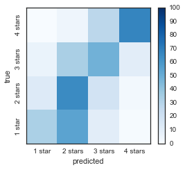

```
4 way accuracy 0.559
4 way f1 0.698
4 way precision 0.725
4 way recall 0.673
```

```python
name='reduced'
print "classifying with %s" %name
summarydf, resultsdf=resultsdict[name]
viz.plotresults(resultsdf, 'true_rating', 'feat_pred')
acc, precision, recall, f1=mo.round2score(resultsdf, 'true_rating', 'feat_pred', compare)
compare['name'].append(name)
```

If all I have on a user is this reduced set of text features, we don't do as well as if we have the full feature vector, but we still perform above chance, suggesting that I can still provide a reasonable new user experience.

### Save all features and reduced space of features (to use with CA data)

```python
featdict={'alltextfeats':descripfeats+numericfeats, 'reducedtextfeats':askfeats}
```

```python
uf.pickletheseobjects(os.path.join(projdir,'learnedfeatures.pkl'),[featdict])
```

```python
comparedf=pd.DataFrame(data=compare)
comparisonlabels=['random','mostfrequent','allterms','user_sim','reduced','combined_reduced','combined']
```

### Assess reliability of model accuracies across users

```python
means,sems,labels=[],[],[]
for x in comparisonlabels:
    vals=resultsdict[x][0].groupby('user').mean().score.values
    #print "%s:  M(std)=%.3f(%.2f), t(%s)=%.3f, p=%.3f" %(x, np.mean(vals), np.std(vals), len(vals)-1, scipy.stats.ttest_1samp(vals, 0)[0], scipy.stats.ttest_1samp(vals, 0)[1])
    means.append(np.mean(vals))
    sems.append(np.std(vals)/np.sqrt(len(vals)))
    labels.append(x)
f,ax=plt.subplots(figsize=[8,3])
ax.bar(range(len(means)), means, yerr=sems)
ax.set_xticks(np.arange(len(means))+.5)
t=ax.set_xticklabels(labels, rotation=90)
```

[output not shown]

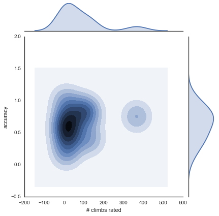

```python
%autoreload
viz.accbyN(resultsdict, usesdf, 'combined_reduced')
```